# 3 vegan - diversity, rarefaction, and species richness

true  
June 25, 2024

# Raw

`?vegdist`: **Gower**, **Bray–Curtis**, indices are good in detecting underlying ecological gradients (Faith et al. 1987). Why using dissimilarity instead similarity?

our samples: rarefaction set to minimal sample size of 5, a descent analysis will take this out and analyse is again.

## Data

We use the data from `Diversity_test_data.xlsx`:

```
tibble [28 × 15] (S3: tbl_df/tbl/data.frame)
 $ transect                 : chr [1:28] "C1" "C4" "C2" "C3" ...
 $ site                     : chr [1:28] "Ancien_lot_de_Marius" "Ancien_lot_de_Marius" "Anketrevo" "Anketrevo" ...
 $ Blaesodactylus_sakalava  : num [1:28] 2 1 4 4 0 1 4 1 1 3 ...
 $ Geckolepis_sp.           : num [1:28] 5 7 1 5 0 5 0 3 3 16 ...
 $ Hemidactylus_spp.        : num [1:28] 3 0 1 0 1 7 2 1 2 1 ...
 $ Lygodactylus_spp.        : num [1:28] 6 2 14 15 1 7 8 8 5 8 ...
 $ Pareodura_bastardi       : num [1:28] 2 0 1 0 1 3 1 5 0 3 ...
 $ Pareodura_picta          : num [1:28] 0 0 0 3 0 0 0 0 0 1 ...
 $ Phelsuma_madagascariensis: num [1:28] 1 2 3 3 1 1 1 2 4 3 ...
 $ Phelsuma_mutabilis       : num [1:28] 0 0 6 6 0 0 2 2 2 4 ...
 $ Uroplatus_guentheri      : num [1:28] 0 1 0 1 1 0 0 2 0 0 ...
 $ latitude                 : num [1:28] -19.9 -19.9 -19.9 -19.9 -19.8 ...
 $ longitude                : num [1:28] 44.7 44.7 44.7 44.7 44.6 ...
 $ elevation                : num [1:28] 110 96 76 85 66 76 62 95 56 64 ...
 $ block                    : chr [1:28] "corridor" "corridor" "corridor" "corridor" ...
```

| transect | site | Blaesodactylus_sakalava | Geckolepis_sp. | Hemidactylus_spp. | Lygodactylus_spp. | Pareodura_bastardi | Pareodura_picta | Phelsuma_madagascariensis | Phelsuma_mutabilis | Uroplatus_guentheri | latitude | longitude | elevation | block |
| --- | --- | --- | --- | --- | --- | --- | --- | --- | --- | --- | --- | --- | --- | --- |
| C1 | Ancien_lot_de_Marius | 2 | 5 | 3 | 6 | 2 | 0 | 1 | 0 | 0 | -19.94752 | 44.71152 | 110 | corridor |
| C4 | Ancien_lot_de_Marius | 1 | 7 | 0 | 2 | 0 | 0 | 2 | 0 | 1 | -19.94807 | 44.70503 | 96 | corridor |
| C2 | Anketrevo | 4 | 1 | 1 | 14 | 1 | 0 | 3 | 6 | 0 | -19.93982 | 44.74053 | 76 | corridor |
| C3 | Anketrevo | 4 | 5 | 0 | 15 | 0 | 3 | 3 | 6 | 1 | -19.94433 | 44.73250 | 85 | corridor |
| N4 | Ambadira | 0 | 0 | 1 | 1 | 1 | 0 | 1 | 0 | 1 | -19.83980 | 44.63180 | 66 | nord |
| N11 | Ambadira | 1 | 5 | 7 | 7 | 3 | 0 | 1 | 0 | 0 | -19.81580 | 44.62065 | 76 | nord |

## Diversity

### Introduction of diversity index

A diversity index is a mathematical measure of speceis diversity in a given community, it is based on the **species richness** (the number of species present) and the **species abundance** (the number of individuals per species).

There are two types of diversity indices:

- dominance indices
- information statistic indices

### Shannon Index (H)

$$H = - \sum^{s}_{i=1}p_i \ln p_i$$

The **Shannon index** is an information statistic index, which means it assumes all species are represented in a sample and that they are randomly sampled, where $p$ is the proportion ($\frac{n}{N}$) of individuals of one particular species found ($n$) divided by the total number of individuals found ($N$), and $s$ is the number of species.

### Simpson index (D)

`vegan::diversity()` calculates the ecological diversity indices, with Shannon index being default, Simpson or Invisimpson index can also be choosed.

```r
simpson <- diversity(community[,3:11], "simpson")
simpson
```

```
 [1] 0.7811634 0.6508876 0.7111111 0.7655223 0.8000000 0.7673611
 [7] 0.7222222 0.8055556 0.7958478 0.7600263 0.7288889 0.7328000
[13] 0.7768595 0.7270233 0.7205707 0.6848073 0.6514048 0.7030827
[19] 0.6419753 0.7249383 0.6582031 0.7109375 0.8253968 0.7596372
[25] 0.7939407 0.6530612 0.6938776 0.7674858
```

```r
shannon <- diversity(community[,3:11])
shannon #Typically ranges from 1.5 - 3.4, higher = more diverse
```

```
 [1] 1.635693 1.303876 1.516585 1.676990 1.609438 1.570313 1.504077
 [8] 1.838994 1.676696 1.703827 1.415369 1.510250 1.641735 1.514601
[15] 1.443926 1.341895 1.178654 1.488168 1.351039 1.525520 1.364706
[22] 1.305096 1.832206 1.618154 1.823135 1.270018 1.419941 1.627474
```

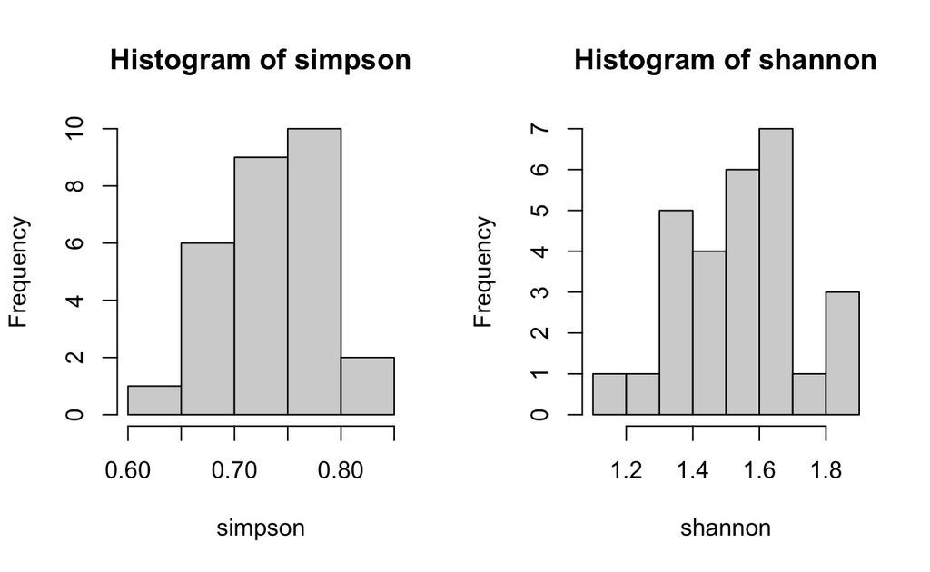

Simpson index shows the probability of randomly drawing two observations given the observations are from different species.

Shannon index gives more importance to rare species, therefore shows higher frequency of the intermediate value.

## Dissimilarity

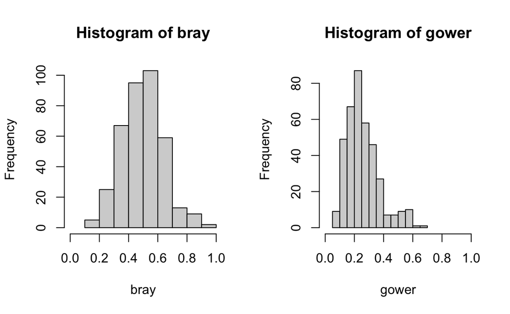

## Rarefaction, Species richness

```r
spAbund <- rowSums(community[,3:11])
spAbund
```

```
 [1] 19 13 30 37  5 24 18 24 17 39 15 25 11 27 29 21 31 43 18 45 32 16
[23] 21 42 67 14 21 23
```

```r
raremin <- min(spAbund)
raremin
```

```
[1] 5
```

```r
sRare <- rarefy(community[1,3:11], sample = raremin)
sRare
```

```
[1] 3.540334
attr(,"Subsample")
[1] 5
```

```r
#tidyrare <- rarecurve(community[,3:11], tidy = TRUE)
#paged_table(tidyrare)
```